# Figuras de la tesis: perfiles diagnósticos (Cap. 2)

Figuras 7, 8, 9 y S1 del documento vigente, embebidas para publicación

Fecha de publicación

11 de octubre de 2026

Documento compañero de publicación: embebe las figuras de perfiles diagnósticos tal como están insertadas en el documento de tesis vigente, con sus pies exactos. No ejecuta análisis; solo empaqueta las imágenes en un HTML autocontenido.

## Figura 8

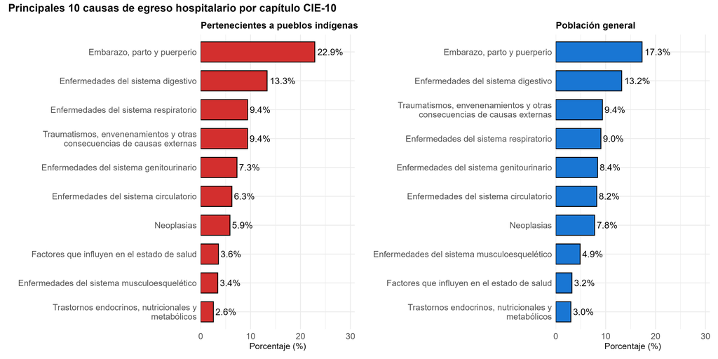

**Figura 8.** Distribución de egresos hospitalarios por capítulo CIE-10 en población indígena y población general. Chile, 2010-2022.

## Figura 7

[figure not shown]

**Figura 7. Patrones diferenciados en representación de pueblos indígenas por grupo diagnóstico CIE-10: estimaciones con intervalos de confianza y evolución temporal. Chile, 2010-2022.** Panel izquierdo: diferencia, en puntos porcentuales (pp), entre la proporción de egresos de población indígena en cada capítulo CIE-10 y la proporción general de población indígena en el total de egresos (13,6%, promedio de las proporciones anuales según la variable enriquecida; la proporción agrupada del período completo es 14,9%); los puntos indican la diferencia promedio sobre los 13 años del periodo (n = 13 puntos anuales) y las barras horizontales representan el intervalo de confianza al 95% (IC95%) estimado mediante aproximación normal. Los puntos rojos señalan sobrerrepresentación (diferencia superior al promedio general); los puntos azules, subrepresentación (diferencia inferior al promedio general). La línea vertical punteada marca la diferencia nula (0 pp). Se incluyen los grupos CIE-10 con diferencia promedio ≥1,5 pp respecto a la línea de referencia. Panel derecho: evolución temporal año a año (2010-2022) de la misma diferencia para los mismos capítulos CIE-10; la intensidad del color representa la magnitud de la diferencia: tonos rojos más intensos indican mayor sobrerrepresentación; tonos azules más intensos, mayor subrepresentación. Variable enriquecida: integración de las tres fuentes administrativas (RSH, CONADI y autodeclaración en EH); pertenencia positiva si la persona figura como perteneciente en al menos una fuente. Fuente: Departamento de Estadísticas e Información de Salud (DEIS), Ministerio de Salud, Chile.

## Figura S1

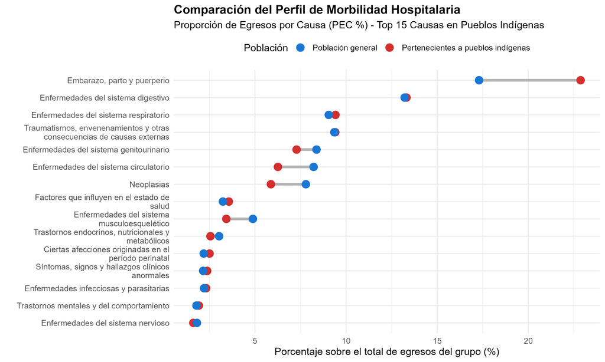

**Figura S1.** Proporciones de egresos hospitalarios por capítulo CIE-10 en población indígena y población general (gráfico de dumbbell). Chile, 2010-2022.

## Figura 9

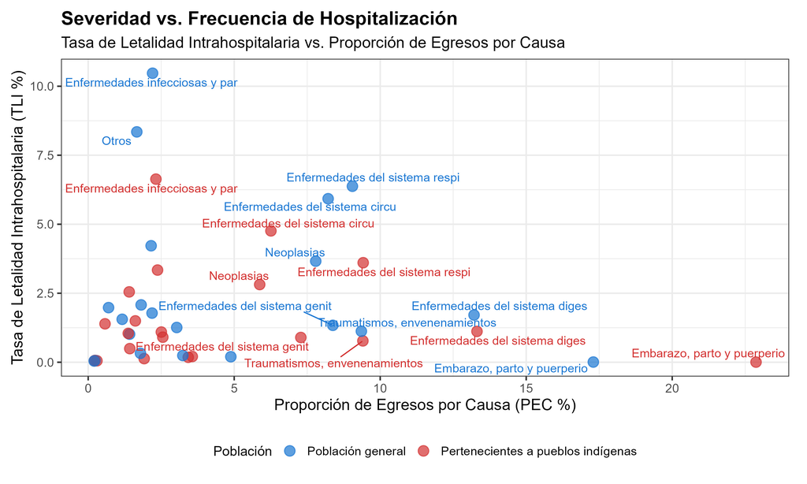